# Modeling and prediction for movies

## Setup

### Load packages

```r
library(ggplot2)
library(dplyr)
library(tibble)
library(statsr)
library(GGally)
```

### Load data

```r
load("movies.Rdata")
movies_data_full <- as_tibble(movies)
```

## Part 1: Data

The data set is comprised of 651 randomly sampled movies produced and released before 2016. Since random sampling was used, data can be generalized to the population. The was no random assignment in this study, so we can’t determine causal relationships between variables, only association between them.

## Part 2: Research question

1. Are the relationships between three score methods (imdb rating, critics score and audience score) linear, and if so, which one has highest correlation coefficients with other two methods? Scores are not a film attributes and we can expect collinearity between them, so we will not use them as a predictors. In our model we have to choose one score as response variable, and this score should have high association with other scores.
2. Which variables should we choose in order to construct multiple linear regression model for prediction of movie popularity?  
   It’s important to find the most impactful predictors for the movie success.
3. What score and uncertainty around it our model predict for the movie “Warcraft”?  
   Fun movie, fun model, let’s predict score and compare it to the real one.

## Part 3: Exploratory data analysis

To answer first question, let’s first select scoring variables. “Imdb rating” goes from 0 to 10, while “critics score” and “audience score” from 0 to 100, so for comparison, let’s adjust Imdb score. Then, let’s check mean and variance them.

```r
movies_scores <- movies_data_full %>%
    select(imdb_rating = imdb_rating, critics_score, audience_score) %>%
    mutate(imdb_rating = imdb_rating*10)
apply(movies_scores, 2, mean)
```

```
##    imdb_rating  critics_score audience_score
##       64.93088       57.68817       62.36252
```

```r
apply(movies_scores, 2, var)
```

```
##    imdb_rating  critics_score audience_score
##       117.6675       806.7288       408.9545
```

“Imdb rating” has much lower variance compared to other two, but higher mean. On the other hand, “critics score” has very high variance. We can take a look at the relationships between all scoring variables using ggpairs() function:

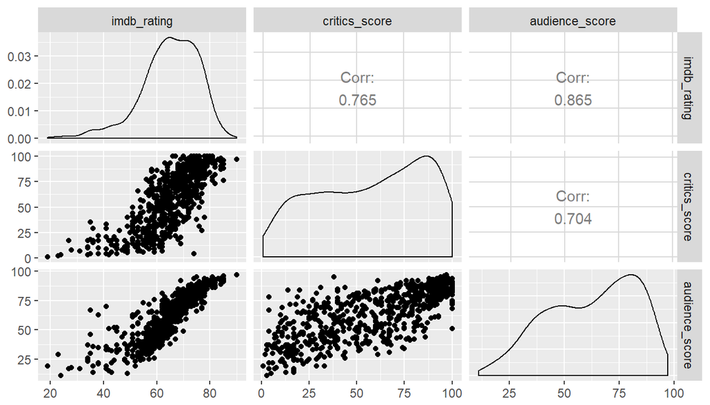

```r
ggpairs(movies_scores[,c("imdb_rating", "critics_score", "audience_score")])
```

## Part 4: Modeling

We need to chose initial set of predictor variables from 31 available. First, lets remove from the set categorical variables (character or factor), that have more then 5 levels (e.g. “title”), as they are already taken into account in other variables, or have too much levels compere to the sample size.

```r
col_selection <- function (col_name) {
    is.numeric(movies_data_full[[col_name]]) ||
    ((is.character(movies_data_full[[col_name]]) ||
    is.factor(movies_data_full[[col_name]])) &&
    length(unique(movies_data_full[[col_name]])) <= 5)
}
column_names <- names(movies_data_full)
movies_data_selected <- movies_data_full[,vapply(column_names, col_selection, logical(1))]
```

Next, let’s eliminated from the set score variables and variables, related to them, as they are not movie parameters.

```r
movies_data_selected <- select(movies_data_selected, -c("imdb_num_votes", "critics_rating", "critics_score",
                                                        "audience_rating", "audience_score"))
```

Also let’s eliminate variables, related to the month and dates of movie released in theaters or on DVD, as it’s actully ordered categorical variable with many levels (12 and 31).

```r
movies_data_selected <- select(movies_data_selected, -c("thtr_rel_month", "dvd_rel_month", "thtr_rel_day",
                                                        "dvd_rel_day"))
movies_data_selected <- movies_data_selected[complete.cases(movies_data_selected),]
names(movies_data_selected)
```

```
##  [1] "title_type"       "runtime"          "thtr_rel_year"
##  [4] "dvd_rel_year"     "imdb_rating"      "best_pic_nom"
##  [7] "best_pic_win"     "best_actor_win"   "best_actress_win"
## [10] "best_dir_win"     "top200_box"
```

For the full model I’m considering variables:  
“title_type” - Type of movie (Documentary, Feature Film, TV Movie)  
“runtime” - Runtime of movie (in minutes)  
“thtr_rel_year” - Year the movie is released in theaters  
“dvd_rel_year” - Year the movie is released on DVD  
“best_pic_nom” - Whether or not the movie was nominated for a best picture Oscar (no, yes)  
“best_pic_win” - Whether or not the movie won a best picture Oscar (no, yes)  
“best_actor_win” - Whether or not one of the main actors in the movie ever won an Oscar (no, yes) – note that this is not necessarily whether the actor won an Oscar for their role in the given movie  
“best_actress_win” - Whether or not one of the main actresses in the movie ever won an Oscar (no, yes) – not that this is not necessarily whether the actresses won an Oscar for their role in the given movie  
“best_dir_win” - Whether or not the director of the movie ever won an Oscar (no, yes) – not that this is not necessarily whether the director won an Oscar for the given movie  
“top200_box” - Whether or not the movie is in the Top 200 Box Office list on BoxOfficeMojo (no, yes)

Now let’s construct the full multiple linear regression model with “imdb_rating” as a responce variable and others as explanatory variables.

```r
fit_lm <- function (movie_df) {
    selected_names <- names(movie_df)
    selected_names <- selected_names[!(selected_names == "imdb_rating")]
    formula_1 <- paste("imdb_rating", paste(selected_names, collapse = " + "), sep = " ~ ")
    fit <- lm(formula = formula_1, data = movie_df)
    fit
}

fit <- fit_lm(movies_data_selected)
summary(fit)
```

```
##
## Call:
## lm(formula = formula_1, data = movie_df)
##
## Residuals:
##     Min      1Q  Median      3Q     Max
## -4.0977 -0.4863  0.0830  0.6020  2.0520
##
## Coefficients:
##                         Estimate Std. Error t value Pr(>|t|)
## (Intercept)            31.629902  17.279584   1.830 0.067651 .
## title_typeFeature Film -1.498943   0.140722 -10.652  < 2e-16 ***
## title_typeTV Movie     -1.734384   0.444378  -3.903 0.000105 ***
## runtime                 0.013442   0.002133   6.301 5.55e-10 ***
## thtr_rel_year          -0.001789   0.004599  -0.389 0.697438
## dvd_rel_year           -0.010807   0.010844  -0.997 0.319367
## best_pic_nomyes         0.955783   0.241559   3.957 8.46e-05 ***
## best_pic_winyes        -0.092105   0.430120  -0.214 0.830509
## best_actor_winyes      -0.035048   0.111610  -0.314 0.753605
## best_actress_winyes     0.028762   0.123455   0.233 0.815855
## best_dir_winyes         0.319578   0.162442   1.967 0.049583 *
## top200_boxyes           0.408591   0.250435   1.632 0.103279
## ---
## Signif. codes:  0 '***' 0.001 '**' 0.01 '*' 0.05 '.' 0.1 ' ' 1
##
## Residual standard error: 0.9453 on 630 degrees of freedom
## Multiple R-squared:  0.2392, Adjusted R-squared:  0.2259
## F-statistic: 18.01 on 11 and 630 DF,  p-value: < 2.2e-16
```

As we want the better predictions from the model, it may be appropriate to use method, which based on maximising r^2. For this I’ve used backward elimination adjusted R^2 method:

```r
backwards_model_selection_r2_main <- function (movies_df, r2) {
    best_names <- NULL
    iter_names <- names(movies_df)[!(names(movies_df) == "imdb_rating")]
    for (variable in iter_names) {
        selected_names <- names(movies_df)
        reduced_names <- selected_names[!(selected_names == variable)]
        selected_names <- reduced_names[!(reduced_names == "imdb_rating")]
        formula_n <- paste("imdb_rating", paste(selected_names, collapse = " + "), sep = " ~ ")
        fit <- lm(formula = formula_n, data = movies_df)
        if (summary(fit)$adj.r.squared > r2) {
            r2 <- summary(fit)$adj.r.squared
            best_names <- reduced_names
        }
    }
    if (is.null(best_names)) {
        list(movies_df, r2)
    } else {
        new_df <- list(movies_df[,best_names], r2)
        new_df
    }
}

recursive_r2 <- function (movies_df, r2) {
    new_df <- backwards_model_selection_r2_main(movies_df, r2)
    if (length(movies_df) == length(new_df[[1]])) {
        movies_df
    } else {
        recursive_r2(new_df[[1]], new_df[[2]])
    }
}

r2 <- summary(fit)$adj.r.squared
simpl_movies <- recursive_r2(movies_data_selected, r2)
fit2 <- fit_lm(simpl_movies)
summary(fit2)
```

```
##
## Call:
## lm(formula = formula_1, data = movie_df)
##
## Residuals:
##     Min      1Q  Median      3Q     Max
## -4.1257 -0.4827  0.0823  0.5990  2.0414
##
## Coefficients:
##                         Estimate Std. Error t value Pr(>|t|)
## (Intercept)            33.417924  16.466894   2.029 0.042835 *
## title_typeFeature Film -1.497577   0.139987 -10.698  < 2e-16 ***
## title_typeTV Movie     -1.730984   0.442467  -3.912 0.000101 ***
## runtime                 0.013408   0.002059   6.512 1.51e-10 ***
## dvd_rel_year           -0.013482   0.008198  -1.644 0.100570
## best_pic_nomyes         0.936888   0.213559   4.387 1.35e-05 ***
## best_dir_winyes         0.311872   0.154849   2.014 0.044427 *
## top200_boxyes           0.412242   0.249047   1.655 0.098363 .
## ---
## Signif. codes:  0 '***' 0.001 '**' 0.01 '*' 0.05 '.' 0.1 ' ' 1
##
## Residual standard error: 0.9426 on 634 degrees of freedom
## Multiple R-squared:  0.2388, Adjusted R-squared:  0.2304
## F-statistic: 28.41 on 7 and 634 DF,  p-value: < 2.2e-16
```

```r
# I just wanted to write some code... and carried away...
```

In this model 6 exploratory variable are used. Now we will make model diagnostics.

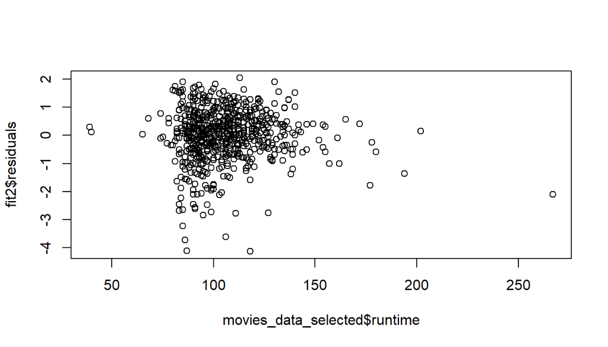

```r
plot(fit2$residuals ~ movies_data_selected$runtime)
```

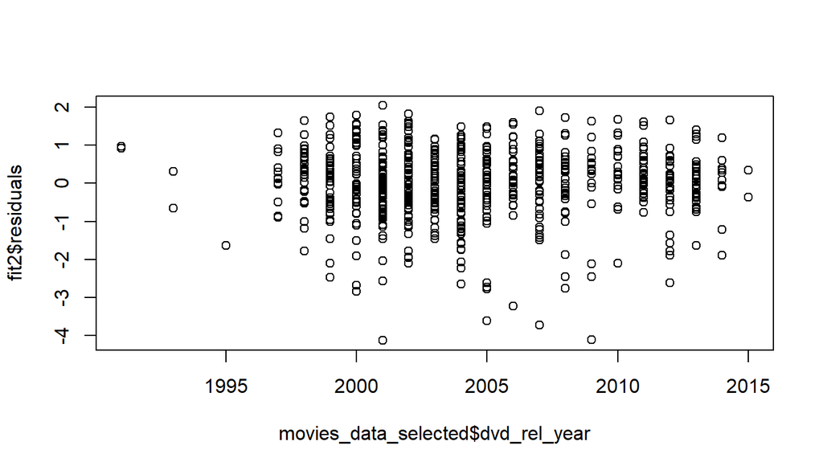

```r
plot(fit2$residuals ~ movies_data_selected$dvd_rel_year)
```

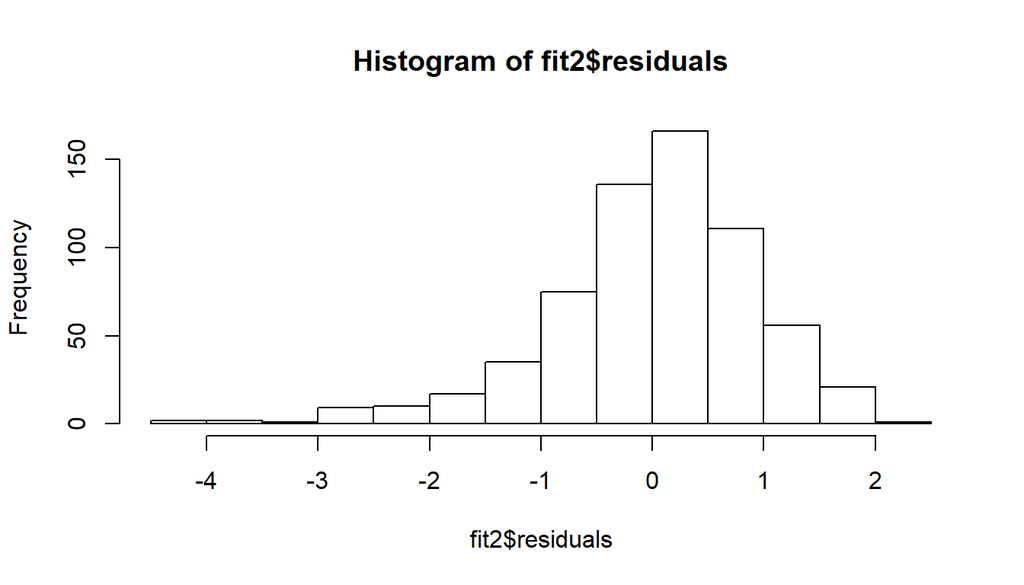

```r
hist(fit2$residuals)
```

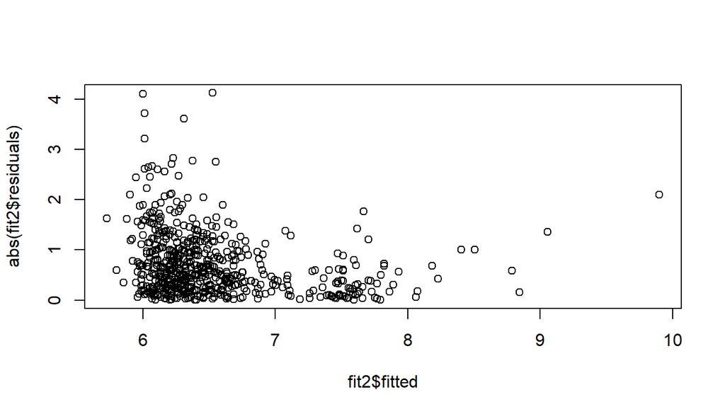

```r
plot(abs(fit2$residuals) ~ fit2$fitted)
```

On the plots of residuals against runtime and dvd_rel_year we can see random scatters (so relationships between numerical exploratory variables and responce variable are linear), on histogram the plot is nearly normal, but variability of the residuals for low and high value of predicted variable is different. Data was obtain by random sampling, so we assume, that the residuales are independent from each other.

Model coefficients may be interpreted this way:  
* All else held constant, for each minute increase in runtime the model predicts the imdb rating to be higher on average by 0.013 units.  
* All else held constant, for each year increase in movie release on DVD date the model predicts the imdb rating to be lower on average by 0.013 units.  
* All else held constant, the model predicts that movie of type “Feature Film” has imdb rating 1.498 lower and movie of type “TV Movie” has imdb rating 1.731 lower than movie of type “Documentary”, on average.  
* All else held constant, the model predicts that movie, which was nominated for a best picture Oscar, has imdb rating 0.937 higher than movie, which was not nominated for a best picture Oscar, on average.  
* All else held constant, the model predicts that movie, whose director did ever win an Oscar, has imdb rating 0.311 higher than movie, whose director did not ever win an Oscar, on average.  
* All else held constant, the model predicts that movie, which is in the Top 200 Box Office list on BoxOfficeMojo, has imdb rating 0.412 higher than movie, which is not in the Top 200 Box Office list on BoxOfficeMojo, on average.

## Part 5: Prediction

Now, let’s pedict imdb rating for a movie “Warcraft”. Data for this movie come from two websites: imdb.com and kinopoisk.ru.

```r
warcraft  <- tibble(
    title_type = "Feature Film",
    runtime = 123,
    dvd_rel_year = 2016,
    imdb_rating = 6.9,
    best_pic_nom = "no",
    best_dir_win = "no",
    top200_box = "no"
)
warcraft_predict <- predict(fit2, warcraft, interval="predict", level = 0.95)
paste0("Predicted IMDB rating: ", round(warcraft_predict[[1]], digits = 4))
```

```
## [1] "Predicted IMDB rating: 6.3905"
```

```r
paste0("Prediction interval: lower ", round(warcraft_predict[2], digits = 4), ", upper ",
       round(warcraft_predict[3], digits = 4))
```

```
## [1] "Prediction interval: lower 4.5263, upper 8.2547"
```

## Part 6: Conclusion

In this study, we used dataset of 651 randomly sampled movies to choose appropriate scoring method, construct prediction model and use it for prediction.  
The full model for prediction Imdb rating contained 10 prediction variables with adjusted R-squared = 0.2259.  
After backward elimination we came to the model, where 6 prediction variables predict imdb raiting with adjusted R-squared = 0.2304.  
Low R-squared value doesn’t allow to say, tha the model will make accurate predictions.

One of the model shortcomings is that some prediction variables in model has revetively high p-values, and their contribution to the model may occure simply by chance. Model is not very parsimonious. The prediction interval for real movie appear to be revatively wide.